# Incarceration Data

## Section 5

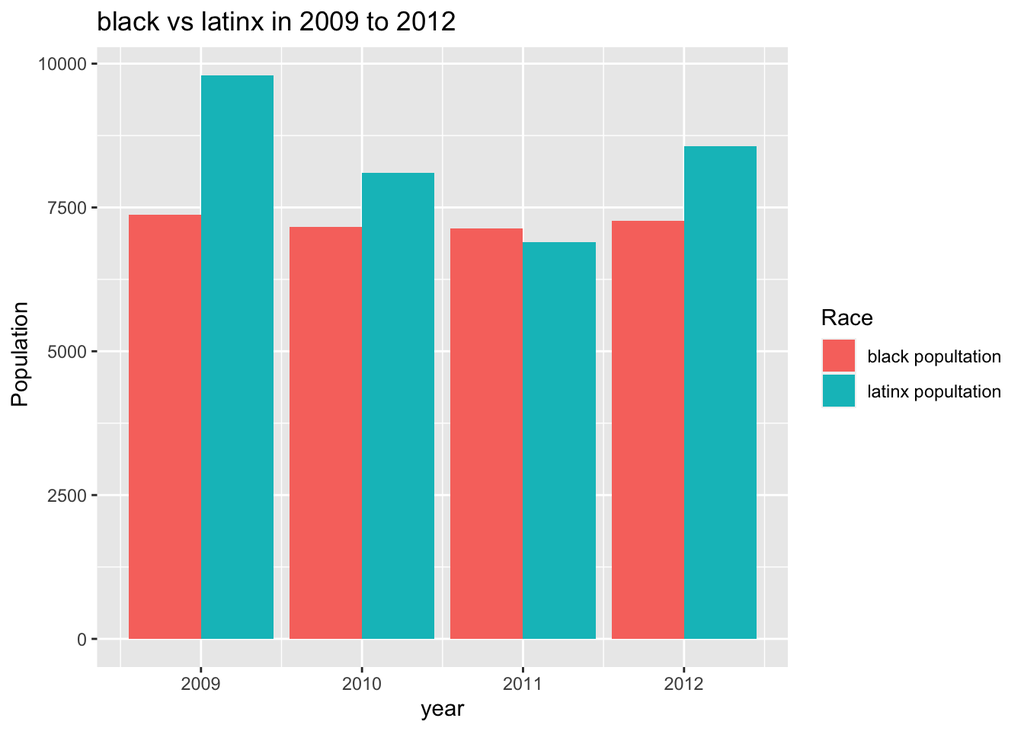

*Caption*: Comparing black and Latinx jail populations in 2009 to 2012.

## Section 6

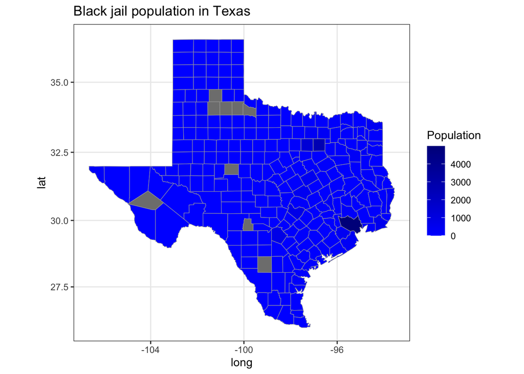

*Caption*: Black jail population in different areas of Texas.

*Summary*: This map shows the jail population in each county in Texas. Most of the counties have a lighter shade which shows that there isn’t a very high population in that area. However, there are three counties on the map that do have a dark shade of blue which shows that the jail population is really high there. A question I have is why is that one area really dark compared to the rest.